# RSY: Collaborative Filtering with Movie Lens Data

### Sources:

https://ds-spaces.technik.fhnw.ch/app/uploads/sites/85/2021/09/hs21_rsy_trainingscenter_minichallenge1_aufgabenstellung-1.pdf https://www.rstudio.com/resources/cheatsheets/ https://cran.r-project.org/web/packages/recommenderlab/recommenderlab.pdf

```r
# Imports
library("tidyverse")
library("recommenderlab")
library("ggplot2")
source("helper.R")
data("MovieLense")
```

## Sampling Data and Save as DF

```r
movie_lens <- sample_movie_lens(size=600, return_df = TRUE)
class(movie_lens)
```

```
[1] "realRatingMatrix"
attr(,"package")
[1] "recommenderlab"
```

# Explorative Datenanalyse

## Task 1

Aufgabe: Untersuche die Eigenschaften der MovieLense Daten und beantworte folgende Fragen: 1. Welches sind die am häufigsten geschauten Genres/Filme? 2. Wie verteilen sich die Kundenratings gesamthaft und nach Genres? 3. Wie verteilen sich die mittleren Kundenratings pro Film? 4. Wie stark streuen die Ratings von individuellen Kunden? 5. Welchen Einfluss hat die Normierung der Ratings pro Kunde auf deren Verteilung? 6. Welche strukturellen Charakteristika (z.B. Sparsity) und Auffälligkeiten zeigt die User-Item Matrix?

### WElches sind die am häufigsten geschauten Filme/Genres?

```r
### Meistgeschaute Filme
movie_idx_counts <- (colSums(movie_lens))
movie_counts <- cbind(colnames(movie_lens), movie_idx_counts)

movie_counts <- as_tibble(movie_counts)
movie_counts <- rename(movie_counts, "name"="V1", "views"="movie_idx_counts")
movie_counts$views <- as.numeric(factor(movie_counts$views))
movie_counts <- arrange(movie_counts, desc(views))


print("Meistgeschaute Filme: ")
```

```
[1] "Meistgeschaute Filme: "
```

```r
print(movie_counts[1:10,])
```

| name | views |
| --- | --- |
| Striptease (1996) | 455 |
| Smilla's Sense of Snow (1997) | 455 |
| Batman & Robin (1997) | 455 |
| Sirens (1994) | 455 |
| Daylight (1996) | 455 |
| Night on Earth (1991) | 455 |
| Citizen Ruth (1996) | 454 |
| Addicted to Love (1997) | 454 |
| Air Force One (1997) | 453 |
| Moll Flanders (1996) | 452 |

```r
### Meistgeschaute Genres
movie_counts_joined <- dplyr::left_join(x = movie_counts, y = MovieLenseMeta, by=c("name" = "title"))

head(movie_counts_joined)
```

| name | views | year | url | unknown | Action | Adventure | Animation | Children's | Comedy | Crime | Documentary | Drama | Fantasy | Film-Noir | Horror | Musical | Mystery | Romance | Sci-Fi | Thriller | War | Western |
| --- | --- | --- | --- | --- | --- | --- | --- | --- | --- | --- | --- | --- | --- | --- | --- | --- | --- | --- | --- | --- | --- | --- |
| Striptease (1996) | 455 | 1996 | http://us.imdb.com/M/title-exact?Striptease%20(1996) | 0 | 0 | 0 | 0 | 0 | 1 | 1 | 0 | 0 | 0 | 0 | 0 | 0 | 0 | 0 | 0 | 0 | 0 | 0 |
| Smilla's Sense of Snow (1997) | 455 | 1997 | http://us.imdb.com/M/title-exact?Smilla%27s%20Sense%20of%20Snow%20(1997) | 0 | 1 | 0 | 0 | 0 | 0 | 0 | 0 | 1 | 0 | 0 | 0 | 0 | 0 | 0 | 0 | 1 | 0 | 0 |
| Batman & Robin (1997) | 455 | 1997 | http://us.imdb.com/M/title-exact?Batman+%26+Robin+(1997) | 0 | 1 | 1 | 0 | 0 | 0 | 1 | 0 | 0 | 0 | 0 | 0 | 0 | 0 | 0 | 0 | 0 | 0 | 0 |
| Sirens (1994) | 455 | 1994 | http://us.imdb.com/M/title-exact?Sirens%20(1994) | 0 | 0 | 0 | 0 | 0 | 1 | 0 | 0 | 1 | 0 | 0 | 0 | 0 | 0 | 0 | 0 | 0 | 0 | 0 |
| Daylight (1996) | 455 | 1996 | http://us.imdb.com/M/title-exact?Daylight%20(1996) | 0 | 1 | 1 | 0 | 0 | 0 | 0 | 0 | 0 | 0 | 0 | 0 | 0 | 0 | 0 | 0 | 1 | 0 | 0 |
| Night on Earth (1991) | 455 | 1991 | http://us.imdb.com/M/title-exact?Night%20on%20Earth%20(1991) | 0 | 0 | 0 | 0 | 0 | 1 | 0 | 0 | 1 | 0 | 0 | 0 | 0 | 0 | 0 | 0 | 0 | 0 | 0 |

[output not shown]

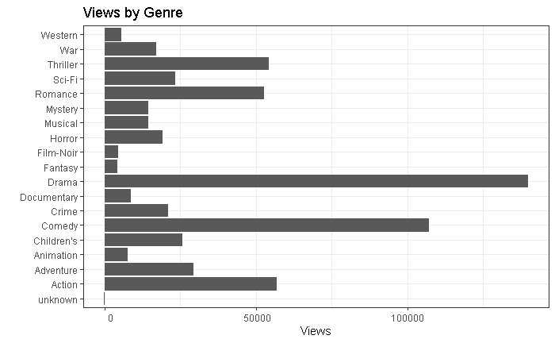

```r
# Select only movie genres
tmp <- movie_counts_joined[, c(5:length(colnames(movie_counts_joined)))]
column_selection <- colnames(tmp)

tmp <- reshape2::melt(data = movie_counts_joined,
            id.vars  = c("views"),
            measure.vars = column_selection,
           variable.name = "genre")

tmp_views <- tmp[tmp$value == 1, ]

tmp_views <- tmp_views %>%
  group_by(genre) %>%
  summarise(viewed_sum = sum(views)) %>%
  arrange(viewed_sum)

ggplot(data = tmp_views, mapping = aes(x = viewed_sum, y = genre)) +
  geom_col() + labs(title = "Views by Genre", x = "Views", y = "") +
  xlim(0, max(tmp_views$viewed_sum)) + scale_x_continuous(labels = function(x) format(x, scientific = FALSE)) + theme_bw()
```

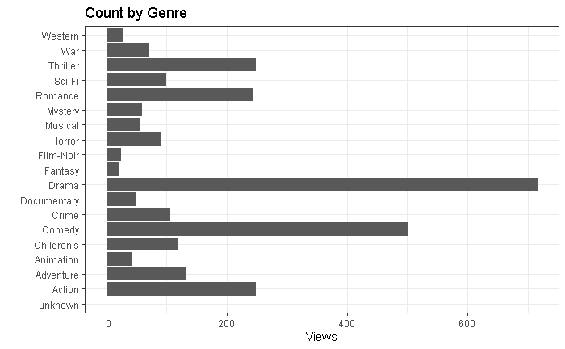

```r
### Anzahl Filme von jedem GEnre im Datensatz
tmp <- tmp[tmp$value == 1, ]

tmp_count <- tmp %>%
  group_by(genre) %>%
  summarise(sum_genre = sum(value))

ggplot(data = tmp_count, mapping = aes(x = sum_genre, y = genre)) +
  geom_col() + labs(title = "Count by Genre", x = "Views", y = "") +
  scale_x_continuous(labels = function(x) format(x, scientific = FALSE)) + theme_bw()
```

**Beschreibung:** Der Plot zeigt das die meistgeschauten Genres Comedy und Drama sind. Die am wenigsten geschauten sind Western, Film-Noir, Fantasy und Animation.

Die Views wiederspiegelen im Grunde die Menge aller Filme im Datensatz. Man kann sehen, dass die Ausbreitung der Bars sehr ähnlich proportional zu den Views ist die in einem GEnre überhaupt drin sind.

### 2. Wie verteilen sich die Kundenratings gesamthaft und nach Genres?

```r
data <- coerce(movie_lens, data.frame())
data
```

|  | user | item | rating |
| --- | --- | --- | --- |
| 2334 | 404 | Braveheart (1995) | 5 |
| 5911 | 404 | While You Were Sleeping (1995) | 4 |
| 24688 | 404 | Jungle2Jungle (1997) | 3 |
| 24806 | 404 | Devil's Own, The (1997) | 3 |
| 25866 | 404 | Contact (1997) | 4 |
| 26191 | 404 | George of the Jungle (1997) | 5 |
| 26706 | 404 | Full Monty, The (1997) | 4 |
| 26898 | 404 | Gattaca (1997) | 4 |
| 27123 | 404 | Good Will Hunting (1997) | 4 |
| 28551 | 404 | English Patient, The (1996) | 1 |

[output cut: 990 more lines]

```r
data <- dplyr::left_join(x = data, y = MovieLenseMeta, by=c("item" = "title"))
data <- reshape2::melt(data = data,
             id.vars  = c("item", "user", "year", "rating"),
             measure.vars = column_selection,
             variable.name = "genre")

data <- data[data$value > 0,]
data$value <- NULL

data
```

|  | item | user | year | rating | genre |
| --- | --- | --- | --- | --- | --- |
| 12365 | unknown | 268 | NA | 3 | unknown |
| 20987 | Good Morning (1971) | 181 | 1971 | 1 | unknown |
| 26709 | unknown | 532 | NA | 3 | unknown |
| 33966 | unknown | 1 | NA | 4 | unknown |
| 44956 | unknown | 130 | NA | 5 | unknown |
| 55899 | unknown | 5 | NA | 4 | unknown |
| 60670 | unknown | 422 | NA | 4 | unknown |
| 64553 | Braveheart (1995) | 404 | 1996 | 5 | Action |
| 64556 | Devil's Own, The (1997) | 404 | 1997 | 3 | Action |
| 64566 | Air Force One (1997) | 404 | 1997 | 4 | Action |

[output cut: 990 more lines]

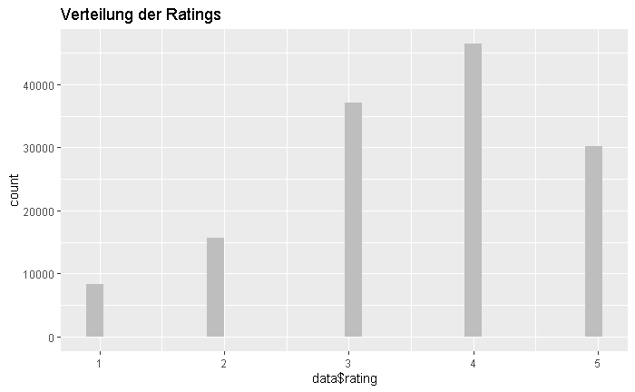

```r
ggplot(data = data, aes(x = data$rating)) +
  geom_histogram(fill='grey') + labs(title = "Verteilung der Ratings")
```

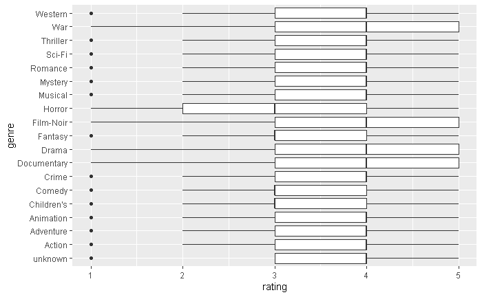

```r
ggplot(data = data, aes(x = rating, y = genre)) +
  geom_boxplot()
```

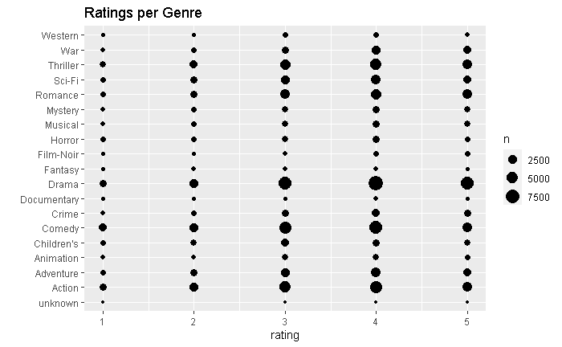

```r
ggplot(data = data, aes(x = rating, y=genre)) +
  geom_count() + labs(y="", title = "Ratings per Genre")
```

```r
NA
NA
NA
```

### 3. Wie verteilen sich die mittleren Kundenratings pro Film?

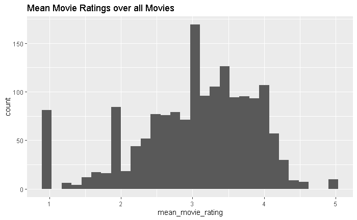

```r
mean_movie_rating <- data %>%
  group_by(item) %>%
  summarise (mean_movie_rating = mean(rating))

ggplot(data = mean_movie_rating, aes(x = mean_movie_rating)) +
  geom_histogram() + labs(title = "Mean Movie Ratings over all Movies")
```

### 4. Wie stark streuen die Ratings von individuellen Kunden?

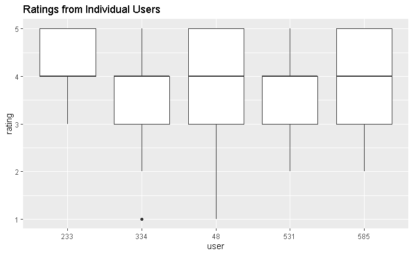

```r
user_samples <- c(sample(data$user, size = 10))

tmp<- data[data$user == user_samples,]
ggplot(data = tmp , aes(x = user, y = rating)) +
  geom_boxplot() + labs(title = "Ratings from Individual Users")
```

### 6. Welche strukturellen Charakteristika (z.B. Sparsity) und Auffälligkeiten zeigt die User-Item Matrix?

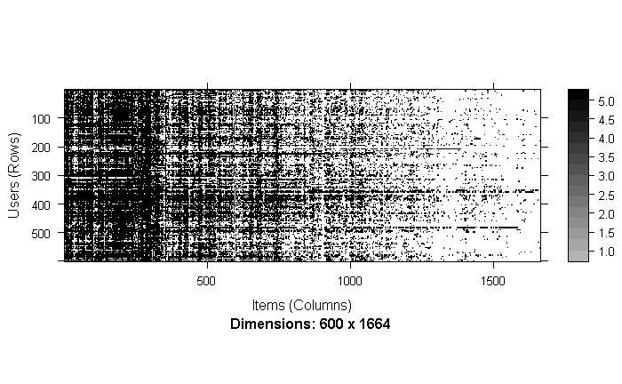

```r
image(movie_lens)
```

**Beschreibung:** Der Plot zeigt die Sparse-Matrix als Heatmap. Die SChwarzen Punkte sind die vorhanden Daten und die weissen zeigen die nicht vorhanden Werten in den Daten. Es wurden 600 Nutzer gesampelt, was hier über die Y-Achse zu sehen ist und der Datensatz hält etwas mehr als 1500 Filme auf der X-Achse. Der Plot zeigt, dass die Filme mit einer höheren ID eher sparse sind als diejenigen mit einer tiefen ID